# Analysis of Environmental Data - Using Models 1

Sarah Guitart

Collaborating Students: Rosalyn Bathrick, Adri Grow, Jailene Gonzalez

### Q1

*Create a histogram of the salamander reproduction catastrophic rates. Make sure you include an appropriate title and label for the x-axis.*

```r
library(here)
catrate <- read.csv(here("data", "catrate.csv"))
head(catrate)
```

|  | pond | success | years | cat.rate |
| --- | --- | --- | --- | --- |
| 1 | 2 | 5 | 7 | 0.2857143 |
| 2 | 3 | 5 | 7 | 0.2857143 |
| 3 | 4 | 6 | 7 | 0.1428571 |
| 4 | 5 | 4 | 7 | 0.4285714 |
| 5 | 6 | 0 | 7 | 1.0000000 |
| 6 | 7 | 1 | 4 | 0.7500000 |

```r
summary(catrate)
```

```
      pond       success          years          cat.rate
 Min.   : 2   Min.   :0.000   Min.   :1.000   Min.   :0.1429
 1st Qu.: 5   1st Qu.:1.000   1st Qu.:3.000   1st Qu.:0.2857
 Median : 8   Median :2.000   Median :4.000   Median :0.4286
 Mean   : 8   Mean   :2.538   Mean   :4.692   Mean   :0.5394
 3rd Qu.:11   3rd Qu.:5.000   3rd Qu.:7.000   3rd Qu.:0.7500
 Max.   :14   Max.   :6.000   Max.   :7.000   Max.   :1.0000
```

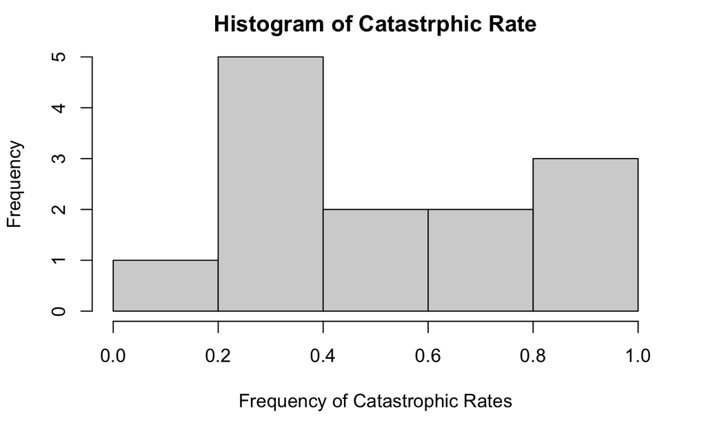

```r
hist(catrate$cat.rate, xlab = "Frequency of Catastrophic Rates",
     main = "Histogram of Catastrphic Rate")
```

### Q2

*Conduct a Shapiro-Wilk test of normality of the salamander catastrophic rates. Report the p-value and show the R-code you used to conduct the test.*

A: The p-value for the Shapiro-Wilk test is 0.0409656.

```r
cat_shapiro = shapiro.test(catrate$cat.rate)
cat_shapiro
```

```
    Shapiro-Wilk normality test

data:  catrate$cat.rate
W = 0.86202, p-value = 0.04097
```

### Q3

*What is the null hypothesis for the Shapiro test?*

A: The null hypothesis for the Shapiro test is that the catastrophic rate data is sampled from a normally distributed population.

### Q4

*Based on the Shapiro test results, is there strong evidence that the sample came from a non-normally-distributed population?*

A: Based on the p-value from our Shapiro test, there is strong evidence that the sample came from a non-normally distributed population.

### Q5

*Show the code you used to conduct the t-test.*

```r
cat_t = t.test(catrate$cat.rate, mu = 2/7)
```

### Q6

*State the null hypothesis of the test, in plain nontechnical English.*

A: The null hypothesis of our t-test is that the average catastrophic rate is not different from the average late-filling rate.

### Q7

*Is this a one- or two-tailed test?*

A: This is a two-tailed test because we’re looking for any difference, smaller or larger.

### Q8

*What is the p-value from your t-test? Interpret the p-value as a false-positive rate using nontechnical English that a non-scientist would understand.*

A: The p-value from my t-test is 0.0119328. A false-positive would be if our t-test told us that the average catastrophic rate is different from the late-filling rate, when actually the two averages are not different. From our p-value, the rate at which we would be told there is a difference when there isn’t would be about 1.2%.

### Q9

*What is the confidence interval for the difference between the null hypothesis and alternative hypothesis means? Did it include zero?*

A: The confidence interval are 0.352625 and 0.7261295, which does not include zero. This means that 95% of the time, the true catastrophic rate average will be between those two values.

### Q10

*Considering the results from your t-test, did you conclude that there was strong evidence to reject the null hypothesis?*

A: Considering the results from our test and the associated p-values from our two-sided t-test, I believe we have sufficient evidence to reject the null hypothesis that the two averages are the same.

### Q11

*Show the code you used to conduct the test.*

```r
cat_wil = wilcox.test(catrate$cat.rate, mu = 2 / 7)
```

### Q12

*Compare the p-value with the p-value you got from the t-test.*

*Considering the results from your rank sum test, did you conclude that there was strong evidence to reject the null hypothesis?*

A: Based on our p-value from the rank sum test, I believe we have sufficient evidence to reject the null hypothesis.

### Q14

*Compare the overall conclusions you could draw from the results of the two tests.*

A: The overall conclusions I can draw from the results of the t-test and the rank sum test is that it is unlikely that the average catastrophic rate is the same as the average late-filling rate. From the t-test, I could also find the sample average and the 95% confidence interval of our sample data.

### Q15

*Considering the numerical and graphical data exploration, which test do you think was more appropriate for these data?*

A: Based on our numerical and graphical data exploration, I think the Wilcoxon Rank Sum Test is more appropriate for these data. From the histogram, we can see that we have a small sample set that is not normally distributed, which is perfect for the Wilcoxon test.

### Q16

*Show the R-code you used to conduct tests of normality for the flipper lengths of Chinstrap and Adelie penguins.*

```r
require(palmerpenguins)
penguin_dat = droplevels(subset(penguins, species != "Gentoo"))
dat_adelie = droplevels(subset(penguin_dat, species == "Adelie"))
dat_chinstrap = droplevels(subset(penguin_dat, species == "Chinstrap"))
adelie_shapiro = shapiro.test(dat_adelie$flipper_length_mm)
chinstrap_shapiro = shapiro.test(dat_chinstrap$flipper_length_mm)
```

### Q17

*Interpret the test results. Do you conclude that the flipper lengths are normally-distributed for each species? Make sure your answers make reference to the test output.*

A: The p-values for our penguin Shapiro tests were 0.7200466 for Adelies and 0.8106447 for the Chinstraps. From these results, I conclude that the flipper lengths are normally distributed for both species.

### Q18

*Save your figure to a file and include it in your report. Your figure needs to have appropriate dimensions such that the two histograms are not vertically stretched.*

```r
png(filename = "penguin_flipper_hists.png",  width = 900, height = 550,
    units = "px")
par(mfrow = c(1, 2))
hist(dat_adelie$flipper_length_mm, main = "Adelie Flipper Lengths",
     xlab = "Flipper Lengths (mm)")
hist(dat_chinstrap$flipper_length_mm, main = "Chinstrap Flipper Lengths",
     xlab = "Flipper Lengths (mm)")
dev.off()
```

### Q19

*State the alternative hypothesis of the test, in plain nontechnical English.*

A: The alternative hypothesis is that the average Adelie flipper length is different from the average Chinstrap flipper length.

### Q20

*Include the code you used to conduct the t-test.*

```r
t.test(flipper_length_mm ~ species, data = penguin_dat)
```

```
    Welch Two Sample t-test

data:  flipper_length_mm by species
t = -5.7804, df = 119.68, p-value = 6.049e-08
alternative hypothesis: true difference in means between group Adelie and group Chinstrap is not equal to 0
95 percent confidence interval:
 -7.880530 -3.859244
sample estimates:
   mean in group Adelie mean in group Chinstrap
               189.9536                195.8235
```